# Assignment 1

Anuraag Vasal

10/22/2021

```r
library(dplyr)
library(readr)
Retailonline <- read.csv("Online_Retail.csv")
```

#The breakdown of the number of transactions by countries

```r
Retailonline_country  <- as.data.frame(table(Retailonline$Country))
Retailonline_country["Percentage"] <- Retailonline_country$Freq/NROW(Retailonline) * 100
names(Retailonline_country) <- c("Country","Count","Percentage")
Retailonline_country[Retailonline_country$Percentage > 1,]
```

```
##           Country  Count Percentage
## 11           EIRE   8196   1.512431
## 14         France   8557   1.579047
## 15        Germany   9495   1.752139
## 36 United Kingdom 495478  91.431956
```

#Countries accounting for more than 1% of the total transactions EIRE,France,Germany and United Kingdom are the 4 countries that accounts for more than 1 % of total transactions.

#Adding new variable ‘TransactionValue’ which is the product of the exising ‘Quantity’ and ‘UnitPrice’ variables.

```r
Retailonline["TransactionValue"] <- Retailonline$Quantity * Retailonline$UnitPrice
head(Retailonline)
```

```
##   InvoiceNo StockCode                         Description Quantity
## 1    536365    85123A  WHITE HANGING HEART T-LIGHT HOLDER        6
## 2    536365     71053                 WHITE METAL LANTERN        6
## 3    536365    84406B      CREAM CUPID HEARTS COAT HANGER        8
## 4    536365    84029G KNITTED UNION FLAG HOT WATER BOTTLE        6
## 5    536365    84029E      RED WOOLLY HOTTIE WHITE HEART.        6
## 6    536365     22752        SET 7 BABUSHKA NESTING BOXES        2
##      InvoiceDate UnitPrice CustomerID        Country TransactionValue
## 1 12/1/2010 8:26      2.55      17850 United Kingdom            15.30
## 2 12/1/2010 8:26      3.39      17850 United Kingdom            20.34
## 3 12/1/2010 8:26      2.75      17850 United Kingdom            22.00
## 4 12/1/2010 8:26      3.39      17850 United Kingdom            20.34
## 5 12/1/2010 8:26      3.39      17850 United Kingdom            20.34
## 6 12/1/2010 8:26      7.65      17850 United Kingdom            15.30
```

#Using the newly created variable, TransactionValue, showing the breakdown of transaction values by countries.

```r
Retailonline%>%group_by(Country)%>%summarise(Total=sum(TransactionValue))
```

```
## # A tibble: 38 x 2
##    Country           Total
##    <chr>             <dbl>
##  1 Australia       137077.
##  2 Austria          10154.
##  3 Bahrain            548.
##  4 Belgium          40911.
##  5 Brazil            1144.
##  6 Canada            3666.
##  7 Channel Islands  20086.
##  8 Cyprus           12946.
##  9 Czech Republic     708.
## 10 Denmark          18768.
## # ... with 28 more rows
```

```r
Retailonline_transactionwise <- Retailonline%>%group_by(Country)%>%summarise(Total=sum(TransactionValue))
```

#Countries with total transaction exceeding 130,000 British Pound.

```r
Retailonline_transactionwise[Retailonline_transactionwise$Total>130000,]
```

```
## # A tibble: 6 x 2
##   Country           Total
##   <chr>             <dbl>
## 1 Australia       137077.
## 2 EIRE            263277.
## 3 France          197404.
## 4 Germany         221698.
## 5 Netherlands     284662.
## 6 United Kingdom 8187806.
```

#Converting ‘InvoiceDate’ into a POSIXlt object

```r
Temp <- strptime(Retailonline $ InvoiceDate,format='%m/%d/%Y %H:%M',tz='GMT')
Retailonline$New_Invoice_Date <- as.Date(Temp)
Retailonline$New_Invoice_Date[20000]- Retailonline$New_Invoice_Date[10]
```

```
## Time difference of 8 days
```

```r
Retailonline$Invoice_Day_Week= weekdays(Retailonline$New_Invoice_Date)
Retailonline$New_Invoice_Hour = as.numeric(format(Temp, "%H"))
Retailonline$New_Invoice_Month = as.numeric(format(Temp, "%m"))
```

#Percentage of transactions (by numbers) by days of the week:

```r
Retailonline%>%group_by(Invoice_Day_Week)%>%summarise(count=n())%>%mutate(percentage=count/nrow(Retailonline)* 100)
```

```
## # A tibble: 6 x 3
##   Invoice_Day_Week  count percentage
##   <chr>             <int>      <dbl>
## 1 Friday            82193       15.2
## 2 Monday            95111       17.6
## 3 Sunday            64375       11.9
## 4 Thursday         103857       19.2
## 5 Tuesday          101808       18.8
## 6 Wednesday         94565       17.5
```

#The percentage of transactions (by transaction volume) by days of the week:

```r
Retailonline%>%group_by(Invoice_Day_Week)%>%summarise(Total=sum(TransactionValue))%>%mutate(percentage=Total/sum(Total)*100)
```

```
## # A tibble: 6 x 3
##   Invoice_Day_Week    Total percentage
##   <chr>               <dbl>      <dbl>
## 1 Friday           1540611.      15.8
## 2 Monday           1588609.      16.3
## 3 Sunday            805679.       8.27
## 4 Thursday         2112519       21.7
## 5 Tuesday          1966183.      20.2
## 6 Wednesday        1734147.      17.8
```

#The percentage of transactions (by transaction volume) by month of the year

```r
Retailonline%>%group_by(New_Invoice_Month)%>%summarise(Total=sum(TransactionValue))%>%mutate(percentage=Total/sum(Total)*100)
```

```
## # A tibble: 12 x 3
##    New_Invoice_Month    Total percentage
##                <dbl>    <dbl>      <dbl>
##  1                 1  560000.       5.74
##  2                 2  498063.       5.11
##  3                 3  683267.       7.01
##  4                 4  493207.       5.06
##  5                 5  723334.       7.42
##  6                 6  691123.       7.09
##  7                 7  681300.       6.99
##  8                 8  682681.       7.00
##  9                 9 1019688.      10.5
## 10                10 1070705.      11.0
## 11                11 1461756.      15.0
## 12                12 1182625.      12.1
```

#The date with the highest number of transactions from Australia

```r
Retailonline%>%
filter(Country=="Australia")%>%
group_by(New_Invoice_Date)%>%
tally(sort = TRUE)%>%
filter(n==max(n))
```

```
## # A tibble: 1 x 2
##   New_Invoice_Date     n
##   <date>           <int>
## 1 2011-06-15         139
```

#The histogram of transaction values from Germany.

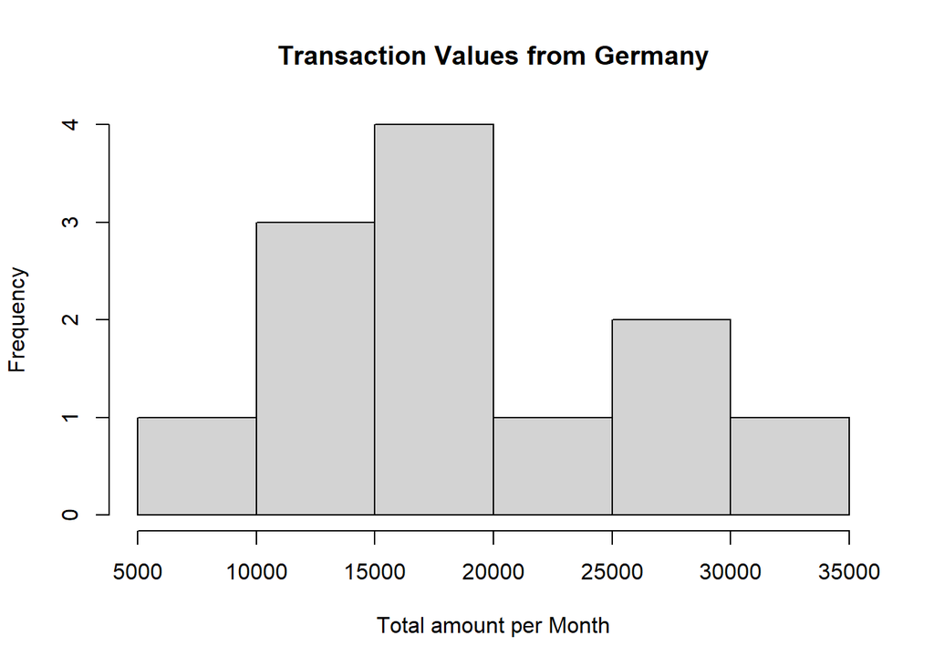

```r
Retailonline%>%
group_by(Country)%>%
filter(Country=="Germany")%>%
group_by(New_Invoice_Month)%>%
summarise(Total = sum(TransactionValue))-> Germany
hist(Germany$Total,main = "Transaction Values from Germany", xlab = "Total amount per Month", ylab = "Frequency")
```

#Customer having the highest number of transactions:

```r
Retailonline%>%
group_by(CustomerID)%>%
tally(sort = TRUE)%>%
filter(!is.na(CustomerID))%>%
filter(n==max(n))
```

```
## # A tibble: 1 x 2
##   CustomerID     n
##        <int> <int>
## 1      17841  7983
```

```r
Retailonline%>%
group_by(CustomerID)%>%
summarise(Total=sum(TransactionValue))%>%
filter(!is.na(CustomerID))%>%
filter(Total == max(Total))
```

```
## # A tibble: 1 x 2
##   CustomerID   Total
##        <int>   <dbl>
## 1      14646 279489.
```

Customer with CustomerID 17841 has the highest number of transactions,and most valuable customer is CustomerID 14646 with spending of 279,489 Pounds.

#The percentage of missing values for each variable in the dataset:

```r
colMeans(is.na(Retailonline) *100)
```

```
##         InvoiceNo         StockCode       Description          Quantity
##           0.00000           0.00000           0.00000           0.00000
##       InvoiceDate         UnitPrice        CustomerID           Country
##           0.00000           0.00000          24.92669           0.00000
##  TransactionValue  New_Invoice_Date  Invoice_Day_Week  New_Invoice_Hour
##           0.00000           0.00000           0.00000           0.00000
## New_Invoice_Month
##           0.00000
```

#The total number of transactions with missing CustomerID records by countries :

```r
NROW(Retailonline[is.na(Retailonline$CustomerID),])
```

```
## [1] 135080
```

The total number of rows in Customer ID column which have missing value is 135080

```r
Retailonline[is.na(Retailonline$CustomerID),] %>% group_by(Country) %>% summarise(count = n())
```

```
## # A tibble: 9 x 2
##   Country         count
##   <chr>           <int>
## 1 Bahrain             2
## 2 EIRE              711
## 3 France             66
## 4 Hong Kong         288
## 5 Israel             47
## 6 Portugal           39
## 7 Switzerland       125
## 8 United Kingdom 133600
## 9 Unspecified       202
```

```r
Retailonline %>%
select(CustomerID,New_Invoice_Date)%>%
group_by(CustomerID)%>%
distinct(New_Invoice_Date)%>%
arrange(desc(CustomerID))%>%
mutate(DaysBetween = New_Invoice_Date - lag(New_Invoice_Date))-> Customerdaysbetweenvisit
Customerdaysbetweenvisit%>%
filter(!is.na(DaysBetween))-> Returningdaysbetweenvisits
mean(Returningdaysbetweenvisits$DaysBetween)
```

```
## Time difference of 38.4875 days
```

#The return rate of the goods purchased by customers from France:

```r
Retailonline_france_cancel <- Retailonline%>%filter(Country=="France",Quantity<0)%>%count
Retailonline_france_total <- Retailonline%>%filter(Country=="France")%>%count
Retailonline_ratio <- Retailonline_france_cancel$n / Retailonline_france_total$n
Retailonline_ratio * 100
```

```
## [1] 1.741264
```

The return rate for Customers of France is 1.741264 %

#The product that has generated the highest revenue for the retailer:

```r
Retailonline%>%group_by(Description)%>%summarise(Total=sum(TransactionValue))%>%arrange((desc(Total)))
```

```
## # A tibble: 4,224 x 2
##    Description                            Total
##    <chr>                                  <dbl>
##  1 "DOTCOM POSTAGE"                     206245.
##  2 "REGENCY CAKESTAND 3 TIER"           164762.
##  3 "WHITE HANGING HEART T-LIGHT HOLDER"  99668.
##  4 "PARTY BUNTING"                       98303.
##  5 "JUMBO BAG RED RETROSPOT"             92356.
##  6 "RABBIT NIGHT LIGHT"                  66757.
##  7 "POSTAGE"                             66231.
##  8 "PAPER CHAIN KIT 50'S CHRISTMAS "     63792.
##  9 "ASSORTED COLOUR BIRD ORNAMENT"       58960.
## 10 "CHILLI LIGHTS"                       53768.
## # ... with 4,214 more rows
```

Doctom Postage is the product that has generated the highest revenue for the retailer.

#Unique customers are represented in the dataset

```r
Retailonline_selectCustID <- Retailonline%>%select(CustomerID)%>%unique %>% nrow
Retailonline_selectCustID
```

```
## [1] 4373
```

The total number of unique customers in the dataset is 4373